# Elections

Taha

6/1/2018

## Introduction

This is a fun big data anaytics project that seeks to uses sentiment analysis to analyse the popularity of political figures in Pakistan. Before we go into the analytics, let us get a bit of a background on the upcoming Pakistani elections.

### Background

Pakistan is a parliamentary democratic republic with a bicameral legislature. Every five years the federal National Assembly alongside the provinical assemblies holds elections. Historically, a number of political parties have contested these elections but in recent times the most popular ones have been Pakistan Muslim League Nawaz (PMLN), Pakistan Tehrik-e-Insaf (PTI) and Pakistan People’s Party (PPP). All three parties have their strongholds in different provinces of the country and contest elections for the national assembly every five years. The party with current majority in the National Assembly is PMLN while regionally PMLN, PTI and PPP have majorities in the Punjab, KPK and Sindh provincial assemblies.

[figure not shown]

For the upcoming elections, all three parties have nominated a candidate for the post of the Prime Minister of Pakistan. The ex-cricketer turned politician Imran Khan is PTI’s candidate, ex-Prime Minister’s brother and popular Chief Minister of Punjab, Shehbaz Sharif is PMLN’s nominee while PPP is backing their Chairman, the son and grandson of ex-Prime Ministers, Bilawal Bhutto.

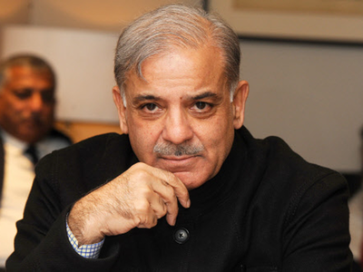

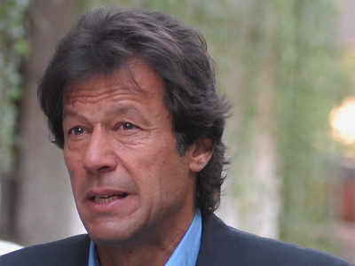

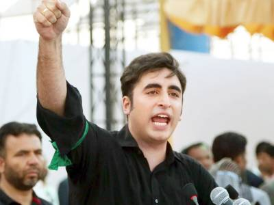

## Getting the Data

I gathered the required data from Twitter through the package `twitteR`. Note that there are other packages that would have worked- `rtweet` is another good one- but this one seems to do the job well enough.

I began by gathering the last 1500 tweets that have mentioned Imran Khan, Shehbaz Sharif and Bilawal Bhutto. The `getFeed()` function creates a list of tweets for a given string and extracts the text from them. Applying it to our vector of candidates gives us the required twitter feeds for them.

```r
candidates <- c("Imran Khan", "Shehbaz Sharif", "Bilawal Bhutto")

getFeed <- function(candidate){
  tweets<- searchTwitter(candidate, n=1500)
  feed<- lapply(tweets, function(x){x$getText()})
  return(feed)
}

candidates_feeds<- sapply(candidates, getFeed)
```

Let us check a tweet to see if we are on the right track.

```r
feed_IK <- candidates_feeds[,"Imran Khan"]
feed_IK[150]
```

```
## [[1]]
## [1] "@RehamKhan1 @Es0t3ric These must be Photoshop right? Well, I dunno anything about it, they are viral on social medi… https://t.co/DZYi0RCdO9"
```

Sounds about right. Now we can break down these tweets into individual words that we can then manipulate. A `getWords()` function that splits the strings along spaces is a good bet. Let’s use it to get all the words for Imran Khan.

```r
getWords<- function(candidate){
  feed <- candidates_feeds[,candidate]
  wordList <- str_split(feed, ' ')
  wordList <- unlist(wordList)
  return(wordList)
}

words_IK <- getWords("Imran Khan")
```

Now you must be, rightly, wondering if we need to clean up this data. We do. Let’s have a look at the most repeated words used in tweets related to Imran Khan.

```r
head(sort(table(words_IK), decreasing = TRUE))
```

```
## words_IK
##    RT Imran  Khan    of    to   the
##  1019   880   788   453   446   431
```

As we can see the most repeated words are Imran Khan’s name, ‘RT’ for retweet and a few commonly used stop words. These are not very insightful and should be removed before any analysis. Let us look at a random range of words in the vector to see if further cleaning is required.

```r
sort(table(words_IK), decreasing = TRUE)[100:120]
```

```
## words_IK
##         makes         we're            be       things…        Khan's
##            49            49            48            48            47
##            ki   @MehrTarar: @ImranKhanPTI    candidates          this
##            47            46            45            45            45
##   @RehamKhan1          123-          125-          126-          Mehr
##            44            43            43            43            43
##    Rashid\nNA     Wajid\nNA       Yasmeen          124-     Iqbal\nNA
##            43            43            43            42            42
##         Walid
##            42
```

We can see that the data is infested with punctuation marks, numbers, hastags, etc. Some tweets are in Urdu, Punjabi and other regional scripts which can not be process. In addition, some words are unnecessarily capitalized while others are not. Finally there must be a lot of words smaller than 3 characters that will probably not be very insightful. We need to rid the data of all these. Thus, we need to modify our `getWords()` function.

```r
getWords <- function(candidate){
  feed <- candidates_feeds[,candidate]
  words <- str_split(feed, ' ')
  words <- unlist(words)
  words <- sub("^*[[:punct:]]", "", words)
  words <- sub("[[:punct:]]*$", "", words)
  # Remove Urdu words
  removeIdx <- which(grepl("[^A-Za-z]", words))
  if (length(removeIdx) > 0){
    words <- words[-removeIdx]
  }
  # Make lower caps
  words <- tolower(words)
  # Remove candidate name, stop words and empty strings.
  candidateName <- tolower(unlist(strsplit(candidate, split = " ")))
  wordsToRemove <- c(stopwords(), candidateName, "RT", c("ppp","pti","pmln", "chairman"))
  words <- words[!(words %in% wordsToRemove) & (words != "") & nchar(words)>2]

  return(words)
}
```

Now we should have clean data to begin our analyses. We can firstly begin by visualizing what were the most used words for these candidates. One way to do that is through a world cloud of the output of our `getWords()` function.

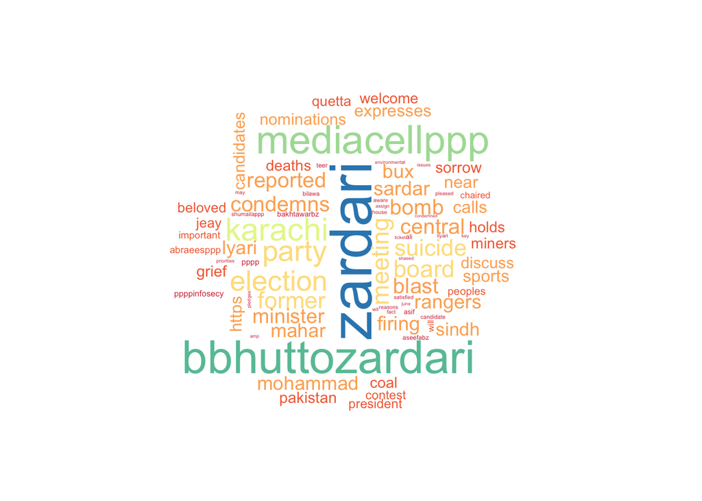

```r
makeWordCloud <- function(candidate){
  pal <- brewer.pal(8,"Spectral")
  words <- getWords(candidate)
  wordcloud(words, max.words = 80, colors = pal, random.order = F, random.color = F, scale=c(3.5,0.1))
}
makeWordCloud('Bilawal Bhutto')
```

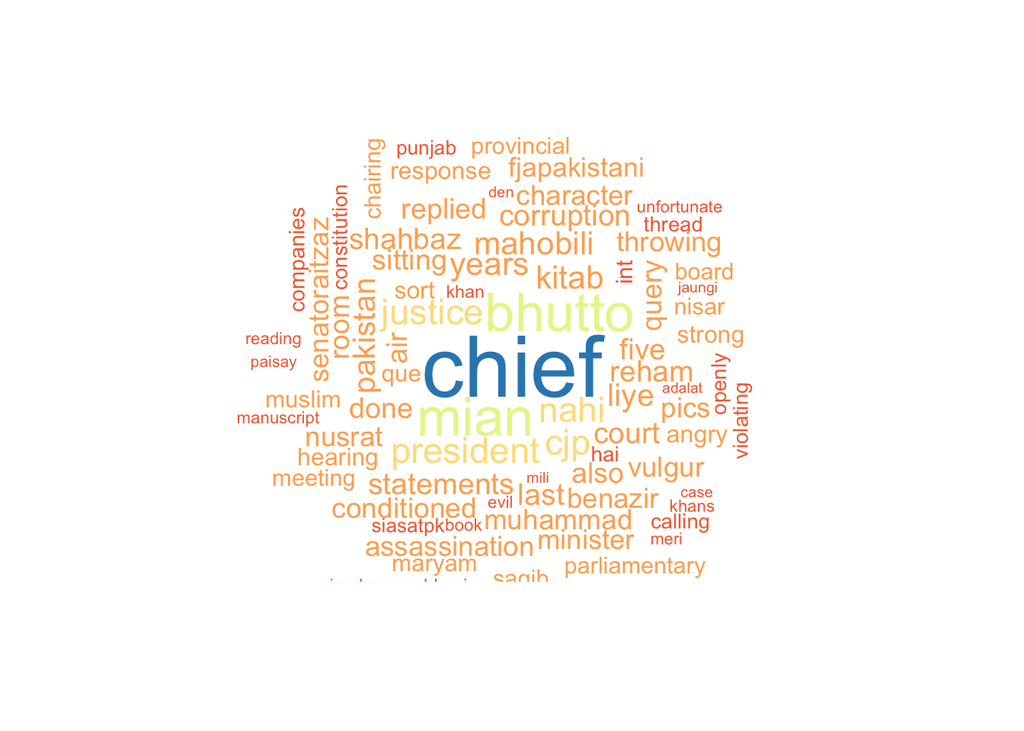

```r
makeWordCloud('Shehbaz Sharif')
```

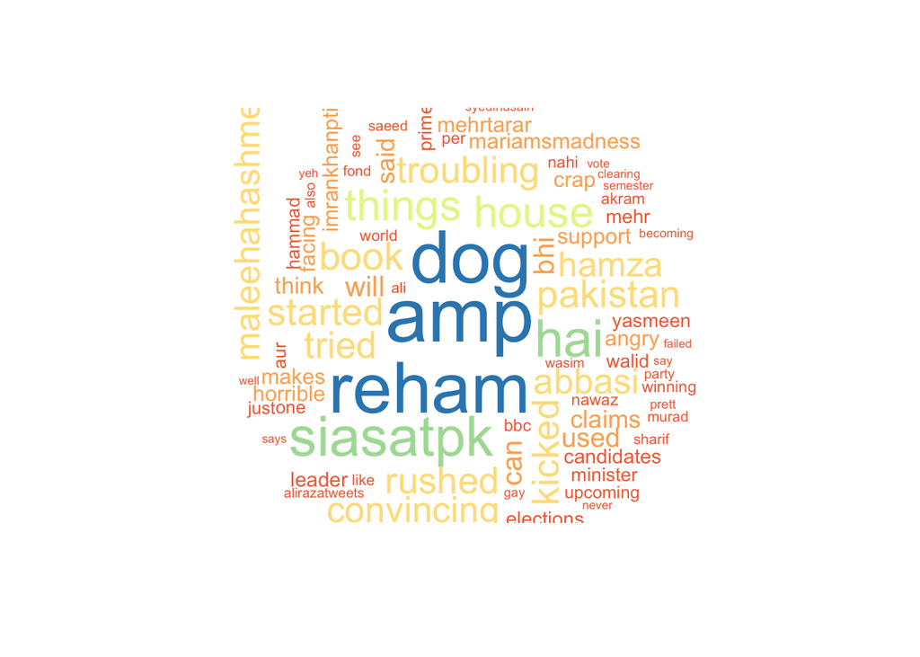

```r
makeWordCloud("Imran Khan")
```

```r
positive_words <- scan('~/Downloads/positive-words.txt',
           what='character', comment.char=';')
negative_words <- scan('~/Downloads/negative-words.txt',
           what='character', comment.char=';')
getOpinionScore <-  function(candidate){
  words <- getWords(candidate)
  positiveMatches <- match(words, positive_words)
  negativeMatches <- match(words, negative_words)
  positiveMatches <- !is.na(positiveMatches)
  negativeMatches <- !is.na(negativeMatches)
  score <- sum(positiveMatches) - sum(negativeMatches)
  return(score)
}
scores <- sapply(candidates, getOpinionScore)
scores
```

```
##     Imran Khan Shehbaz Sharif Bilawal Bhutto
##             26            -93           -566
```

Let us display this in a nice bar plot.

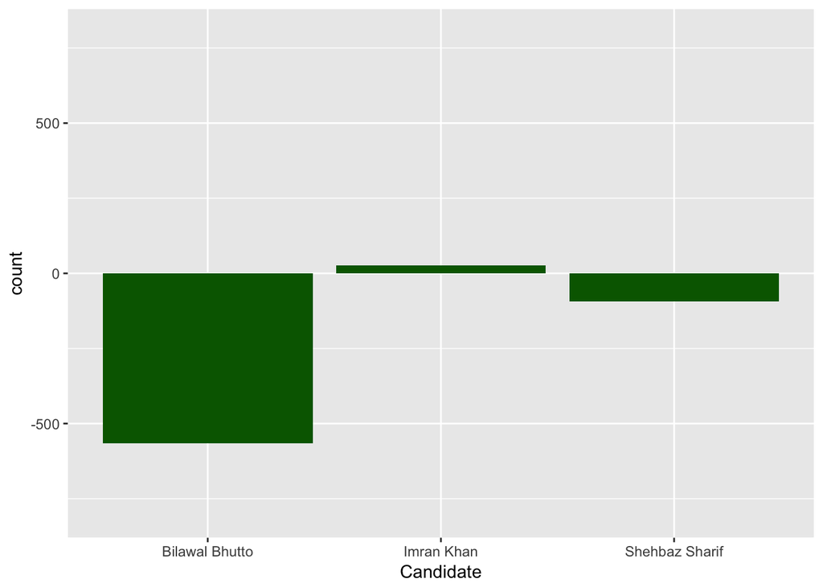

```r
scoresdf<-data.frame(Candidate = candidates,
           Score = scores)
ggplot(scoresdf, aes(x=Candidate, weight=Score))+
  geom_bar(fill="dark green") + ylim(c(-800, 800))
```

Seems like people have a somewhat neutral opinion of Imran Khan and Shehbaz Sharif while Bilawal Bhutto seems very unpopular. This does in fact align with recent results that show the Imran Khan’s and Shehbaz Sharif’s parties have performed far better in polls including in the last general election 5 years ago.